# Practical Machine Learning Project

Beth Calub

December 1, 2018

## Background

Using devices such as Jawbone Up, Nike FuelBand, and Fitbit it is now possible to collect a large amount of data about personal activity relatively inexpensively. These type of devices are part of the quantified self movement – a group of enthusiasts who take measurements about themselves regularly to improve their health, to find patterns in their behavior, or because they are tech geeks. One thing that people regularly do is quantify how much of a particular activity they do, but they rarely quantify how well they do it. In this project, your goal will be to use data from accelerometers on the belt, forearm, arm, and dumbell of 6 participants. They were asked to perform barbell lifts correctly and incorrectly in 5 different ways. More information is available from the website here: http://web.archive.org/web/20161224072740/http:/groupware.les.inf.puc-rio.br/har (see the section on the Weight Lifting Exercise Dataset).

## Data

The training data for this project are available here:

https://d396qusza40orc.cloudfront.net/predmachlearn/pml-training.csv

The test data are available here:

https://d396qusza40orc.cloudfront.net/predmachlearn/pml-testing.csv

### Loading the library needed for the processing.

```r
library(caret)
library(randomForest)
library(rpart)
```

## DOWNLOADING AND CLEANING DATA

The files were downloaded from the https://d396qusza40orc.cloudfront.net/predmachlearn/pml-training.csv and ttps://d396qusza40orc.cloudfront.net/predmachlearn/pml-testing.csv

### Download necessary files

```r
download.file("https://d396qusza40orc.cloudfront.net/predmachlearn/pml-testing.csv", destfile="pm1-testing.csv")
download.file("https://d396qusza40orc.cloudfront.net/predmachlearn/pml-training.csv", destfile="pm1-training.csv")
```

### Reading the data from the download file and assigning them to variables to start the processing.

### Read needed CSV files

```r
TRset <- read.csv("pm1-training.csv")
TEset <- read.csv("pm1-testing.csv")
```

### Initialize data for processing

```r
TRset0 <- createDataPartition(TRset$classe, p=0.7, list=FALSE)
TRset1 <- TRset[TRset0,]
TEset1 <- TRset[-TRset0,]
```

### remove near zero variables and NA values

The data contains a lot of variables as seen from running the dim() function. Some of these variables contain “NA” values and Near Zero Variance hence it needs to be cleaned from them.

```r
Zero <- nearZeroVar(TRset1)
Zero <- nearZeroVar(TRset1)
TRset1 <- TRset1[,-Zero]
TEset1 <- TEset1[,-Zero]
dim(TRset1)
```

```
## [1] 13737   106
```

```r
dim(TEset1)
```

```
## [1] 5885  106
```

```r
NAvalues <- sapply(TRset1,function(x) mean(is.na(x))) > 0.95
TRset1 <- TRset1[, NAvalues == FALSE]
TEset1 <- TEset1[, NAvalues == FALSE]
```

Process needed values

```r
TRset1 <- TRset1[,-(1:5)]
TEset1 <- TEset1[,-(1:5)]
set.seed(34561)
```

## PREDICTION MODEL BUILDING

For the project, there will be two methods that are being considered for the model. One of which is the Random Forest and the Decision Tree. A confusion matrix is plotted at the end of each method to get the accuracy of the models.

### RANDOM FOREST:

```r
RFcont <- trainControl(method="cv", number=3, verboseIter = FALSE)
RFfit <- train(classe ~ ., data=TRset1, method = "rf", trControl = RFcont)
RFfit$finalModel
```

```
##
## Call:
##  randomForest(x = x, y = y, mtry = param$mtry)
##                Type of random forest: classification
##                      Number of trees: 500
## No. of variables tried at each split: 27
##
##         OOB estimate of  error rate: 0.23%
## Confusion matrix:
##      A    B    C    D    E class.error
## A 3906    0    0    0    0 0.000000000
## B    4 2649    4    1    0 0.003386005
## C    0    5 2389    2    0 0.002921536
## D    0    0   10 2241    1 0.004884547
## E    0    0    0    4 2521 0.001584158
```

```r
RFpredict <- predict(RFfit, newdata = TEset1)
RFCMatrix <- confusionMatrix(RFpredict, TEset1$classe)
RFCMatrix
```

```
## Confusion Matrix and Statistics
##
##           Reference
## Prediction    A    B    C    D    E
##          A 1672    4    0    0    0
##          B    1 1135    2    0    0
##          C    0    0 1024    1    0
##          D    0    0    0  962    1
##          E    1    0    0    1 1081
##
## Overall Statistics
##
##                Accuracy : 0.9981
##                  95% CI : (0.9967, 0.9991)
##     No Information Rate : 0.2845
##     P-Value [Acc > NIR] : < 2.2e-16
##
##                   Kappa : 0.9976
##  Mcnemar's Test P-Value : NA
##
## Statistics by Class:
##
##                      Class: A Class: B Class: C Class: D Class: E
## Sensitivity            0.9988   0.9965   0.9981   0.9979   0.9991
## Specificity            0.9991   0.9994   0.9998   0.9998   0.9996
## Pos Pred Value         0.9976   0.9974   0.9990   0.9990   0.9982
## Neg Pred Value         0.9995   0.9992   0.9996   0.9996   0.9998
## Prevalence             0.2845   0.1935   0.1743   0.1638   0.1839
## Detection Rate         0.2841   0.1929   0.1740   0.1635   0.1837
## Detection Prevalence   0.2848   0.1934   0.1742   0.1636   0.1840
## Balanced Accuracy      0.9989   0.9979   0.9989   0.9989   0.9993
```

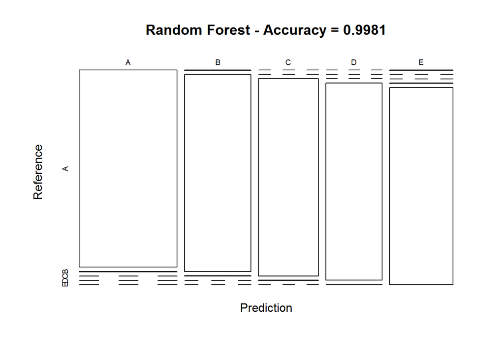

```r
plot(RFCMatrix$table, col = RFCMatrix$byClass, main = paste("Random Forest - Accuracy =", round(RFCMatrix$overall['Accuracy'],4)))
```

### using decision tree fro the prediction

```r
set.seed(34561)
DTree <- rpart(classe ~., data=TRset1, method = "class")
DTpredict <- predict(DTree, newdata=TEset1, type="class")
DTCmatrix <- confusionMatrix(DTpredict, TEset1$classe)
DTCmatrix
```

```
## Confusion Matrix and Statistics
##
##           Reference
## Prediction    A    B    C    D    E
##          A 1558  268   50  125   98
##          B   45  646   80   36   94
##          C   10   75  803  129   72
##          D   40   90   69  580   62
##          E   21   60   24   94  756
##
## Overall Statistics
##
##                Accuracy : 0.738
##                  95% CI : (0.7265, 0.7492)
##     No Information Rate : 0.2845
##     P-Value [Acc > NIR] : < 2.2e-16
##
##                   Kappa : 0.6655
##  Mcnemar's Test P-Value : < 2.2e-16
##
## Statistics by Class:
##
##                      Class: A Class: B Class: C Class: D Class: E
## Sensitivity            0.9307   0.5672   0.7827  0.60166   0.6987
## Specificity            0.8715   0.9463   0.9411  0.94696   0.9586
## Pos Pred Value         0.7423   0.7170   0.7374  0.68966   0.7916
## Neg Pred Value         0.9694   0.9011   0.9535  0.92387   0.9339
## Prevalence             0.2845   0.1935   0.1743  0.16381   0.1839
## Detection Rate         0.2647   0.1098   0.1364  0.09856   0.1285
## Detection Prevalence   0.3567   0.1531   0.1850  0.14291   0.1623
## Balanced Accuracy      0.9011   0.7567   0.8619  0.77431   0.8286
```

[figure not shown]

```r
plot(DTCmatrix$table, col = DTCmatrix$byClass, main = paste ("Decision Tree - Accuracy = ", round(DTCmatrix$overall['Accuracy'])))
```

## MODEL FOR THE TEST DATA:

Comparing the two methods, it can be seen that Random Forest will be able to have a good prediction, hence it will be adopted for this project. Below is the output for the prediction model.

### Applying the chosen method as a prediction model

```r
Tpredict <- predict(RFfit, newdata=TEset)
Tpredict
```

```
##  [1] B A B A A E D B A A B C B A E E A B B B
## Levels: A B C D E
```